# D213_task2

**Western Governors University (WGU)**

**Advanced Data Analytics — D213**

**Task 2: Sentiment Analysis Using Neural Networks**

**Natallia Zimnitskaya | ID: 012247127**

**Master of Science, Data Analytics**

**PART I**

**A 1. RESEARCH QUESTION**

Can we determine customer sentiment by applying sentiment analysis to the combined Amazon and Yelp reviews datasets?

This question is highly relevant to organizations as it helps businesses understand customer opinions and satisfaction levels. We can analyze these sentiments using neural network models and NLP techniques, providing valuable insights into customer feedback and improving service quality.

**A 2. OBJECTIVES OR GOALS**

- Preprocessing and cleaning the combined dataset of Amazon and Yelp reviews.
- Tokenizing and transforming the text data into a format suitable for model training.
- Train and evaluate a neural network model to ensure it delivers high accuracy and reliable predictions.
- Generating actionable insights to help businesses enhance their products and services based on customer feedback.

**A 3. PRESCRIBED NETWORK** I will use a Feedforward Neural Network (FNN) for this task. It is an artificial neural network characterized by node connections that do not form loops. The structure includes an input layer, one or more hidden layers, and an output layer. Information travels in a single direction—from input to output—giving it the name “feedforward” (GeeksforGeeks, 2024). Additionally, the model includes an Embedding layer to convert text into dense vectors, and a GlobalAveragePooling1D layer to reduce dimensionality. These layers allow the model to learn patterns and context within the text, making it well-suited for performing sentiment analysis on the combined dataset of Amazon and Yelp reviews. By leveraging both the structure of FNNs and the capabilities of embeddings and pooling layers, this hybrid model can produce accurate and valuable predictions on text sequences

**PART II**

**B 1. DATA EXPLORATION**

To prepare my dataset for this assessment, I used an adaptation for a code provided by Dr.Elleh in his PowerPoint presentation for the D213 Task 2 webinar (Elleh, n.d.-b).

**Data exploration steps:**

**1. Data Overview:**

The chosen dataset comprises 2,000 reviews from Amazon and Yelp, with an equal distribution of 1,000 negative reviews and 1,000 positive reviews. The data includes two primary columns: 'review' containing the text of the review and 'sentiment' indicating the sentiment label (0 for negative and 1 for positive).

**2. Summary Statistics:**

**3. Missing Data Analysis:**

The dataset was checked for missing values, and any null entries in the 'review' or 'sentiment' columns were removed to ensure data quality. A heatmap visualization confirmed that there were no remaining null values after the cleanup.

**4. Data Visualization:**

Several visualizations were employed to explore the dataset. A bar chart depicting the distribution of sentiments showed a balanced split between positive and negative reviews.

**5. Data Cleaning and Preprocessing:**

**Presence of Unusual Characters:** During my exploratory data analysis, I identified the presence of unusual characters in the review texts, such as punctuation and special characters like "! ;)". These characters were subsequently removed. I also ensured there were no non-English characters or emojis in the dataset.

**Vocabulary Size:** After cleaning the text and tokenizing the reviews, I built a vocabulary from the combined Amazon and Yelp reviews. The total vocabulary size is 3284 unique words.

**Proposed Word Embedding Length:** Based on the vocabulary size, the proposed word embedding length is calculated as the fourth root of the vocabulary size, resulting in an embedding length of approximately 7.57.

**Statistical Justification for the Chosen Maximum Sequence Length:** I analyzed the review lengths to determine the maximum sequence length for the reviews. The maximum review length is 147 characters, the minimum is zero, and the mean length is 54.35. I chose a maximum sequence length of 70 words, as it covers most reviews while avoiding excessive padding.

```python
!pip install spacy
!python -m spacy download en_core_web_sm
```

```
     ━━━━━━━━━━━━━━━━━━━━━━━━━━━━━━━━━━━━━━━━ 12.8/12.8 MB 55.9 MB/s eta 0:00:00
✔ Download and installation successful
You can now load the package via spacy.load('en_core_web_sm')
⚠ Restart to reload dependencies
If you are in a Jupyter or Colab notebook, you may need to restart Python in
order to load all the package's dependencies. You can do this by selecting the
'Restart kernel' or 'Restart runtime' option.
```

```python
#import packages and libraries
import numpy as np
import pandas as pd
import string
import re
from pandas import Series, DataFrame
import nltk
import matplotlib.pyplot as plt
import seaborn as sns
import warnings
from sklearn.model_selection import train_test_split
import os
import datetime
import statistics
import tensorflow as tf
import keras
from tensorflow.keras import Sequential
from tensorflow.keras.layers import Embedding, LSTM, Dense, Dropout, SpatialDropout1D
from tensorflow.keras.preprocessing.text import Tokenizer
from tensorflow.keras.preprocessing.sequence import pad_sequences
from nltk.corpus import stopwords
from nltk.tokenize import word_tokenize
from textblob import TextBlob
from wordcloud import WordCloud, STOPWORDS, ImageColorGenerator
from sklearn.feature_extraction.text import CountVectorizer
from PIL import Image
import plotly.express as px
from nltk.stem import PorterStemmer, WordNetLemmatizer
from nltk.sentiment import SentimentIntensityAnalyzer
from tensorflow.keras.callbacks import ModelCheckpoint, EarlyStopping

#avoid inline warnings
warnings.filterwarnings('ignore')
%matplotlib inline
```

```python
#set working directory
os.getcwd()
```

```
'/content'
```

```python
#read the files
amazon = pd.read_csv("amazon_cells_labelled.txt", sep="\t", header=None, names=["text", "label"])

yelp = pd.read_csv("yelp_labelled.txt", sep="\t", header=None, names=["text", "label"])

#concatenate the datasets
df = pd.concat([amazon, yelp], ignore_index=True)

#view the combined dataframe
print(df.head())
print("Shape of combined dataframe:", df.shape)
```

```
                                                text  label
0  So there is no way for me to plug it in here i...      0
1                        Good case, Excellent value.      1
2                             Great for the jawbone.      1
3  Tied to charger for conversations lasting more...      0
4                                  The mic is great.      1
Shape of combined dataframe: (2000, 2)
```

```python
#get dataset info
df.info()
```

```
<class 'pandas.core.frame.DataFrame'>
RangeIndex: 2000 entries, 0 to 1999
Data columns (total 2 columns):
 #   Column  Non-Null Count  Dtype
---  ------  --------------  -----
 0   text    2000 non-null   object
 1   label   2000 non-null   int64
dtypes: int64(1), object(1)
memory usage: 31.4+ KB
```

```python
#rename columns
df = df.rename(columns={'text': 'review', 'label': 'sentiment'})
```

```python
#convert 'review' to lowercase string
df['review'] = df['review'].astype(str).str.lower()

#convert 'sentiment' to int
df['sentiment'] = df['sentiment'].astype(int)
```

```python
#check for na's
df.isna().sum()
```

|  | 0 |
| --- | --- |
| review | 0 |
| sentiment | 0 |

**dtype:** int64

```python
#drop nas
df = df.dropna()
#check for nulls
df.isnull().sum()
```

|  | 0 |
| --- | --- |
| review | 0 |
| sentiment | 0 |

**dtype:** int64

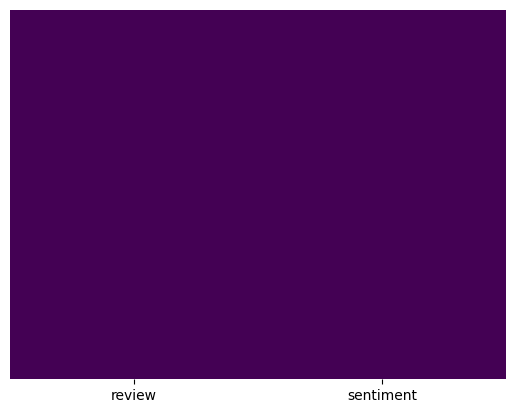

```python
#visualize if any missing data presents
sns.heatmap(df.isnull(), yticklabels=False, cbar=False, cmap='viridis')
```

```python
#get the statistics
df.describe()
```

|  | sentiment |
| --- | --- |
| count | 2000.000000 |
| mean | 0.500000 |
| std | 0.500125 |
| min | 0.000000 |
| 25% | 0.000000 |
| 50% | 0.500000 |
| 75% | 1.000000 |
| max | 1.000000 |

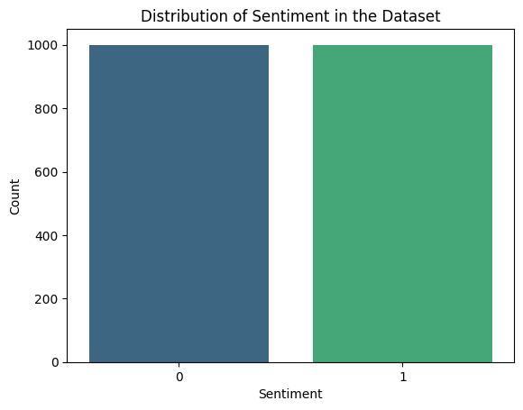

```python
# FOR B4 RUBRIC CATEGORIES OF SENTIMENT

##categorize sentiment with 0 being negative and 1 positive
df['sentiment'] = df['sentiment'].apply(lambda x: 0 if x == 0 else 1)

#plotting the distribution of sentiments in the dataset
sns.countplot(x='sentiment', data=df, palette='viridis')
plt.xlabel('Sentiment')
plt.ylabel('Count')
plt.title('Distribution of Sentiment in the Dataset')
plt.show()
```

```python
df['sentiment'].value_counts()
```

| sentiment | count |
| --- | --- |
| 0 | 1000 |
| 1 | 1000 |

**dtype:** int64

```python
#percent of positive and negative reviews
df.sentiment.value_counts() / len(df)
```

| sentiment | count |
| --- | --- |
| 0 | 0.5 |
| 1 | 0.5 |

**dtype:** float64

**- Presence of Unusual Characters:** During my exploratory data analysis, I identified the presence of unusual characters in the review texts, such as punctuation and special characters like "! ;)". These characters were subsequently removed. I also ensured there were no non-English characters or emojis in the dataset.

```python
#the review text contains punctuation and special characters like ! ;)
pd.set_option('display.max_colwidth', 5000)
df.head(10)
```

|  | review | sentiment |
| --- | --- | --- |
| 0 | so there is no way for me to plug it in here in the us unless i go by a converter. | 0 |
| 1 | good case, excellent value. | 1 |
| 2 | great for the jawbone. | 1 |
| 3 | tied to charger for conversations lasting more than 45 minutes.major problems!! | 0 |
| 4 | the mic is great. | 1 |
| 5 | i have to jiggle the plug to get it to line up right to get decent volume. | 0 |
| 6 | if you have several dozen or several hundred contacts, then imagine the fun of sending each of them one by one. | 0 |
| 7 | if you are razr owner...you must have this! | 1 |
| 8 | needless to say, i wasted my money. | 0 |
| 9 | what a waste of money and time!. | 0 |

Presence of non-English characters:

```python
# Function to identify unusual characters in a text
def find_special_characters(text):
    # Find unusual characters that are not letters, numbers, or whitespace
    unusual_characters = re.findall(r'[^a-zA-Z0-9\s]', text)
    return unusual_characters

# Apply the function to the 'review' column and collect all unusual characters
all_special_characters = df['review'].apply(find_special_characters)

# Flatten the list of lists into a single list
all_special_characters = [char for sublist in all_special_characters for char in sublist]

# Get the unique unusual characters
unique_special_characters = set(all_special_characters)

print("Unique Special Characters: ", unique_special_characters)
```

```
Unique Special Characters:  {',', '%', '$', '?', 'ê', '/', '&', ')', '-', '"', '!', '*', '[', 'é', '+', '#', '(', '.', ']', ':', "'", ';'}
```

Presence of emojis in text:

```python
pip install emoji
```

```python
import emoji

# Function to check if a character is an emoji
def is_emoji(char):
    return char in emoji.EMOJI_DATA

# Function to identify emojis in a text
def find_emojis(text):
    # Find emojis in the text
    emojis = [char for char in text if is_emoji(char)]
    return emojis

# Apply the function to the 'review' column and collect all emojis
all_emojis = df['review'].apply(find_emojis)

# Flatten the list of lists into a single list
all_emojis = [char for sublist in all_emojis for char in sublist]

# Get the unique emojis
unique_emojis = set(all_emojis)

print("Unique Emojis: ", unique_emojis)
```

```
Unique Emojis:  set()
```

No emojis were found in the text.

```python
#remove punctuation
df.review = df.review.str.replace(r'[^\w\s]+', '')
```

```python
#remove text within parenthesis
df.review = df.review.str.replace(r'\(.*\)', '', regex=True)
```

```python
#strip leading and trailing whitespace
df.review = df.review.str.strip()
```

Removing of special chatacters:

```python
#remove special characters that are not a word character or whitespace
def remove_special_characters(text):
    text = re.sub(r'[^\w\s]', '', text)
    return text

#apply to the 'review'
df['review'] = df['review'].apply(remove_special_characters)

#view the updated dataframe
df.head()
```

|  | review | sentiment |
| --- | --- | --- |
| 0 | so there is no way for me to plug it in here in the us unless i go by a converter | 0 |
| 1 | good case excellent value | 1 |
| 2 | great for the jawbone | 1 |
| 3 | tied to charger for conversations lasting more than 45 minutesmajor problems | 0 |
| 4 | the mic is great | 1 |

```python
#add review_length column
df['review_length'] = df.review.str.len()
```

```python
#get first five reviews
df.head()
```

|  | review | sentiment | review_length |
| --- | --- | --- | --- |
| 0 | so there is no way for me to plug it in here in the us unless i go by a converter | 0 | 81 |
| 1 | good case excellent value | 1 | 25 |
| 2 | great for the jawbone | 1 | 21 |
| 3 | tied to charger for conversations lasting more than 45 minutesmajor problems | 0 | 76 |
| 4 | the mic is great | 1 | 16 |

```python
#length of reviews
length_reviews = df.review.str.len()

#determine the type of the length_reviews object
print(type(length_reviews))
```

```
<class 'pandas.core.series.Series'>
```

**- Statistical Justification for the Chosen Maximum Sequence Length:** I analyzed the review lengths to determine the maximum sequence length for the reviews. The maximum review length is 147 characters, the minimum is zero, and the mean length is 54.35. I chose a maximum sequence length of 70 words, as it covers most reviews while avoiding excessive padding.

```python
#get maximum, minimum, and mean lengths, formatting mean to 2 decimal places
max_length = length_reviews.max()
min_length = length_reviews.min()
mean_length = length_reviews.mean()

print(f"Maximum length of reviews: {max_length}")
print(f"Minimum length of reviews: {min_length}")
print(f"Mean length of reviews: {mean_length:.2f}")
```

```
Maximum length of reviews: 147
Minimum length of reviews: 0
Mean length of reviews: 54.35
```

**- Vocabulary Size:** After cleaning the text and tokenizing the reviews, I built a vocabulary from the combined Amazon and Yelp reviews. The total vocabulary size is 3284 unique words.

**- Proposed Word Embedding Length:** Based on the vocabulary size, the proposed word embedding length is calculated as the fourth root of the vocabulary size, resulting in an embedding length of approximately 7.57.

```python
#convert 'review' to a list
reviews = df['review'].tolist()

#initialize variables
vocab = []
max_review_len = 70

#find the maximum review length
for review in reviews:
    review_len = len(review.split(" "))
    if review_len > max_review_len:
        max_review_len = review_len

#build the vocabulary from all reviews
for review in reviews:
    for word in review.split(" "):
        if word not in vocab:
            vocab.append(word)

#print the results
print("Vocab:  ", len(vocab))
print("Longest:  ", max_review_len)
print("Emb Size:  ", len(vocab)**0.25)
```

```
Vocab:   3284
Longest:   70
Emb Size:   7.570085542949803
```

**B 2. TOKENIZATION**

The primary goal of the tokenization process in this sentiment analysis project is to convert raw text data into a structured format that can be effectively used for training a neural network model.

Tokenization breaks down the text into individual words or tokens, making it easier to analyze and process.

**Packages used:**

**re** for regular expressions to remove special characters.

**nltk** for stopwords removal and downloading necessary data files.

**spacy** for tokenization and lemmatization.

**The steps taken:**

**Normalization:** I used the re library to remove special characters and punctuation, ensuring that the text only contains alphanumeric characters and spaces. This step reduces noise in the data.

**Tokenization and Lemmatization:** I used the spacy English model to tokenize the text into individual words and perform lemmatization, which converts words to their base forms. This step helps reduce different word forms to a single representation. Stopwords, which are common words that do not contribute much to the meaning (e.g., “the” and “is”), were removed using nltk stopwords.

**Lemmatizer and Stemmer Demonstration:** I downloaded the necessary nltk data files and initialized a lemmatizer and a stemmer using NLTK's WordNetLemmatizer and PorterStemmer. I demonstrated the use of these tools by printing the original, stemmed, and lemmatized forms of a list of demo words. The demoWords list is a set of sample words that show how text preprocessing works, including various forms of verbs, nouns, and adjectives.

```python
import spacy

#download  nltk data files
nltk.download('stopwords')

#load spacy English model
nlp = spacy.load("en_core_web_sm")

#prepare stop words
stop_words = set(stopwords.words('english'))

#create description list
description_list = []

for description in df['review']:
    #remove punctuations and special characters
    description = re.sub("[^a-zA-Z]", " ", description)

    #convert to lower case
    description = description.lower()

    #perform tokenization and lemmatization
    doc = nlp(description)
    description = [token.lemma_ for token in doc if not token.is_punct and not token.is_space]

    #removing stopwords
    description = [word for word in description if word not in stop_words]

    #join the words back into a single string
    description = " ".join(description)

    description_list.append(description)
```

```python
print(stop_words)
```

```
{'by', 'of', "i'm", 'where', "you'll", "you've", "it'll", 'me', "wasn't", 'weren', 'before', 'are', 'their', 'mightn', 'at', 'as', 'against', 's', 'about', 'which', 'will', 'shan', 'all', 'have', 'having', "hadn't", "that'll", 'any', 'no', 'during', 'yours', 'been', 'didn', "we've", 'then', 'does', …
```

```python
#download necessary nltk files
nltk.download('wordnet')
nltk.download('punkt')

#create list of demo words
demoWords = [
    "making", "going", "go", "do", "does", "doing",
    "yes", "no", "having", "had", "jumping",
    "coding", "programming", "code", "runner", "running",
    "ran", "dogs", "dog", "plays", "played",
    "playing", "beautiful", "beauty", "better", "best",
    "worse", "worst", "child", "children", "cities"
]

#initialize lemmatizer and stemmer
lemmatizer = WordNetLemmatizer()
stemmer = PorterStemmer()

#print original, stemmed, and lemmatized words
for word in demoWords:
    print(word, stemmer.stem(word), lemmatizer.lemmatize(word, "v"))
```

```
making make make
going go go
go go go
do do do
does doe do
doing do do
yes ye yes
no no no
having have have
had had have
jumping jump jump
coding code cod
programming program program
code code code
runner runner runner
running run run
ran ran run
dogs dog dog
dog dog dog
plays play play
played play play
playing play play
beautiful beauti beautiful
beauty beauti beauty
better better better
best best best
worse wors worse
worst worst worst
child child child
children children children
cities citi cities
```

```python
#display first five 5 reviews
description_list[0:5]
```

```
['way I plug us unless I go converter',
 'good case excellent value',
 'great jawbone',
 'tie charger conversation last minutesmajor problem',
 'mic great']
```

**B 3. PADDING PROCESS**

The padding process is used to standardize the length of sequences in my dataset so that they can be processed efficiently by the neural network model.

This involves adding extra tokens (typically zeros) to each sequence so that all sequences are the same length.

• Padding Location: padding occurs after the text sequence in this project. This means that if a sequence is shorter than the desired length, zeros are added at the end of the sequence to make up the difference.

• Implementation: I used the pad_sequences function from the tensorflow.keras.preprocessing.sequence module to achieve this.

Please see the padded sequence example for the first review below:

```python
#tokenize and pad sequences
reviews = description_list
tokenizer = Tokenizer(num_words=8000)
tokenizer.fit_on_texts(reviews)
encoded_docs = tokenizer.texts_to_sequences(reviews)
padded_sequence = pad_sequences(encoded_docs, maxlen=52, padding='post')

#print a sample result
print("Padded Sequence Example: ", padded_sequence[0])
```

```
Padded Sequence Example:  [  72    1  134 1085  450    1    9 1086    0    0    0    0    0    0
    0    0    0    0    0    0    0    0    0    0    0    0    0    0
    0    0    0    0    0    0    0    0    0    0    0    0    0    0
    0    0    0    0    0    0    0    0    0    0]
```

```python
print(tokenizer.word_index)
```

[output not shown]

```python
#encoded and padded reviews example
print(reviews[0])
print(encoded_docs[0])
```

```
way I plug us unless I go converter
[72, 1, 134, 1085, 450, 1, 9, 1086]
```

**B 4. CATEGORIES OF SENTIMENT**

In this sentiment analysis project, I am using two categories of sentiment: 0 for negative sentiment and 1 for positive sentiment.

I will use the sigmoid activation function for the final dense layer of the neural network. This activation function is suitable for binary classification tasks because it outputs a probability value between 0 and 1, indicating the likelihood of the input belonging to the positive sentiment category.

**B 5. STEPS TO PREPARE THE DATA**

To prepare the data for analysis, I followed these steps to ensuring that the data is correctly structured for building a neural network model:

**1. Import libraries and packages:** such as NumPy, Pandas, TensorFlow, Keras, NLTK, and SpaCy to facilitate data preprocessing, analysis, and modeling.

**2. Load and read datasets:** Load Amazon and Yelp datasets into data frames and read and store the data files in data frames for further processing.

**3. Concatenate datasets:** Combine the datasets into a single data frame to create a unified dataset for analysis.

**4. Preprocess data:** Rename columns for clarity and consistency, convert review text to lowercase to maintain uniformity, and convert sentiment labels to integer type for easier handling.

**5. Categorize sentiment:** Map sentiment values to 0 (negative) and 1 (positive) and visualize the distribution of sentiments using bar charts.

**6. Identify unusual characters:** Identify and print unique special characters and emojis in the reviews to understand the presence of unusual characters in the dataset.

**7. Clean Text:** Remove punctuation, special characters, text within parentheses, and leading/trailing whitespaces; calculate and print the length of the reviews to understand the distribution of text lengths.

**8. Vocabulary and sequence preparation:** Convert reviews to a list, build the vocabulary, determine the maximum review length, and tokenize and pad the sequences to ensure uniform sequence lengths.

**9. Tokenization and lemmatization:** Tokenize and lemmatize the text using nltk and spacy, remove stop words, and prepare a cleaned description list.

**10. Convert description_list to array:** Convert the cleaned description list to a NumPy array for easier handling and analysis.

**11. Create training and test sets:** Split the data into training and test sets, with the test set size being 20% of the data, which is a common industry standard; use the stratify parameter to ensure that the class distribution of sentiments is maintained in both the training and test sets.

**12. Create validation set:** Create a validation set from the training set with a size of 20% of the training set; following standard practice, use the stratify parameter again to maintain the class distribution.

**13. Convert sentiment labels to series:** Convert sentiment labels for the training, validation, and test sets to Pandas series for easier handling and analysis.

**14. Verify data splits:** Print the sizes of the training, validation, and test sets to verify that the splits were performed correctly.

**15. Prepare sequences for model training:** Fit the tokenizer on the training data, convert texts to sequences and pad them to ensure uniform length across all samples.

**16. Final preparation:** Convert padded sequences and labels to NumPy arrays for model input, preparing them for training the neural network model.

```python
X = np.array(description_list)
y = df.sentiment.values

#create training and test sets
X_train, X_test, y_train, y_test = train_test_split(
    X, y, test_size=0.20, random_state=15, stratify=y
)

#create validation set from the training set
X_train, X_validation, y_train, y_validation = train_test_split(
    X_train, y_train, test_size=0.20, random_state=73, stratify=y_train
)

#convert y sets to pandas series
y_train = pd.Series(y_train)
y_test = pd.Series(y_test)
y_validation = pd.Series(y_validation)

print("X Shape: ",X.shape)
print("y Shape: ",y.shape)
print("X_train Shape: ",X_train.shape)
print("X_test Shape: ",X_test.shape)
print("y_train Shape: ",y_train.shape)
print("y_test Shape: ",y_test.shape)
```

```
X Shape:  (2000,)
y Shape:  (2000,)
X_train Shape:  (1280,)
X_test Shape:  (400,)
y_train Shape:  (1280,)
y_test Shape:  (400,)
```

```python
#find the maximum review length from the training data
max_review_length = max(len(review.split(" ")) for review in X_train)

#initialize and fit the tokenizer
tokenizer = Tokenizer(oov_token='<OOV>')
tokenizer.fit_on_texts(X_train)

#get word count and index dictionary
word_count = tokenizer.word_index
print('Size of data vocab: ', len(word_count) + 1)

#convert texts to sequences
train_sequences = tokenizer.texts_to_sequences(X_train)
test_sequences = tokenizer.texts_to_sequences(X_test)

#pad the sequences
train_padded = pad_sequences(train_sequences, padding='post', maxlen=max_review_length)
test_padded = pad_sequences(test_sequences, padding='post', maxlen=max_review_length)

print("Training sequences shape: ", train_padded.shape)
print("Testing sequences shape: ", test_padded.shape)
```

```
Size of data vocab:  1927
Training sequences shape:  (1280, 18)
Testing sequences shape:  (400, 18)
```

```python
import random

#get a random sample from the word count dictionary
word_sample = random.sample(list(word_count.items()), min(7, len(word_count)))

print('Random sample from word count dictionary:', word_sample)
```

```
Random sample from word count dictionary: [('ready', 1545), ('hard', 146), ('favor', 1882), ('listen', 637), ('boost', 1348), ('excelent', 1105), ('palm', 463)]
```

```python
#convert training texts to sequences
sequences_train = tokenizer.texts_to_sequences(X_train)

#display the tokenized sequences
print(sequences_train)
```

[output not shown]

```python
import sys

#display the padded sequence for the second training sample
np.set_printoptions(threshold=sys.maxsize)
print(train_padded[1])

#verify shapes
print('X_train Shape: {}\nX_test Shape: {}\nX_validation Shape: {}'.format(
    X_train.shape, X_test.shape, X_validation.shape))
```

```
[ 3 31  2 19  0  0  0  0  0  0  0  0  0  0  0  0  0  0]
X_train Shape: (1280,)
X_test Shape: (400,)
X_validation Shape: (320,)
```

```python
#convert padded data to numpy array to be used in model.
training_padded = np.array(train_padded)
training_label = np.array(y_train)
test_padded = np.array(test_padded)
test_label = np.array(y_test)
```

**B 6. PREPARED DATA SET**

Please see the files attached along with the submission.

```python
#export padded train/test data
pd.DataFrame(train_padded).to_csv('X_training_df.csv', index=False)
pd.DataFrame(test_padded).to_csv('X_testing_df.csv', index=False)
pd.DataFrame(training_label).to_csv('y_training_df.csv', index=False)
pd.DataFrame(test_label).to_csv('y_testing_df.csv', index=False)
pd.DataFrame(X_validation).to_csv('X_validation_df.csv', index=False)
pd.DataFrame(y_validation).to_csv('y_validation_df.csv', index=False)
```

**PART III**

**C 1. MODEL SUMMARY**

```python
#convert review column to a list
reviews = df['review'].tolist()

#initialize variables
vocab = []
max_review_len = 70

#find the maximum review length
for review in reviews:
    review_len = len(review.split(" "))
    if review_len > max_review_len:
        max_review_len = review_len

#build the vocabulary from all reviews
for review in reviews:
    for word in review.split(" "):
        if word not in vocab:
            vocab.append(word)

vocab_size = len(vocab) + 1
embedding_dim = int(len(vocab)**0.25)

#convert reviews to sequences using tokenizer
tokenizer = Tokenizer(oov_token="<OOV>")
tokenizer.fit_on_texts(reviews)
sequences = tokenizer.texts_to_sequences(reviews)
padded_sequences = pad_sequences(sequences, maxlen=max_review_len, padding='post')

#define early_stopping_monitor
early_stopping_monitor = EarlyStopping(patience=2)

#build the model
model = tf.keras.Sequential([
    tf.keras.layers.Embedding(vocab_size, embedding_dim, input_length=max_review_len),
    tf.keras.layers.Dropout(0.2),
    tf.keras.layers.GlobalAveragePooling1D(),
    tf.keras.layers.Dense(100, activation='relu'),
    tf.keras.layers.Dense(50, activation='relu'),
    tf.keras.layers.Dense(1, activation='sigmoid') #final dence layer with sigmoid activation
])

#build the model by feeding some sample input data
model.build(input_shape=(None, max_review_len))

#compile the model
model.compile(loss='binary_crossentropy', optimizer='adam', metrics=['accuracy', 'AUC'])

#print the model summary
model.summary()
```

```
Model: "sequential"
```

```
┏━━━━━━━━━━━━━━━━━━━━━━━━━━━━━━━━━━━━━━┳━━━━━━━━━━━━━━━━━━━━━━━━━━━━━┳━━━━━━━━━━━━━━━━━┓
┃ Layer (type)                         ┃ Output Shape                ┃         Param # ┃
┡━━━━━━━━━━━━━━━━━━━━━━━━━━━━━━━━━━━━━━╇━━━━━━━━━━━━━━━━━━━━━━━━━━━━━╇━━━━━━━━━━━━━━━━━┩
│ embedding (Embedding)                │ (None, 70, 7)               │          22,995 │
├──────────────────────────────────────┼─────────────────────────────┼─────────────────┤
│ dropout (Dropout)                    │ (None, 70, 7)               │               0 │
├──────────────────────────────────────┼─────────────────────────────┼─────────────────┤
│ global_average_pooling1d             │ (None, 7)                   │               0 │
│ (GlobalAveragePooling1D)             │                             │                 │
├──────────────────────────────────────┼─────────────────────────────┼─────────────────┤
│ dense (Dense)                        │ (None, 100)                 │             800 │
├──────────────────────────────────────┼─────────────────────────────┼─────────────────┤
│ dense_1 (Dense)                      │ (None, 50)                  │           5,050 │
├──────────────────────────────────────┼─────────────────────────────┼─────────────────┤
│ dense_2 (Dense)                      │ (None, 1)                   │              51 │
└──────────────────────────────────────┴─────────────────────────────┴─────────────────┘
```

```
 Total params: 28,896 (112.88 KB)
```

```
 Trainable params: 28,896 (112.88 KB)
```

```
 Non-trainable params: 0 (0.00 B)
```

The model summary output from TensorFlow details a sequential neural network used for sentiment analysis.

The architecture includes an embedding layer with 22995 parameters, a dropout layer, a GlobalAveragePooling1D layer, a dense layer with 100 nodes and 800 parameters, a second dense layer with 50 nodes and 5050 parameters, and a final dense layer with one node and 51 parameters, utilizing sigmoid activation.

The total number of parameters in the model is 28896, all trainable.

This summary accurately reflects the neural network architecture tailored for text classification tasks.

**C 2. NETWORK ARCHITECTURE**

The neural network model for sentiment analysis is composed of six distinct layers.

It begins with an embedding layer, which converts the text input into dense vectors and contains 22995 parameters.

Following this is a dropout layer designed to prevent overfitting by randomly setting a fraction of input units to zero during training; this layer has no trainable parameters.

The next layer is a GlobalAveragePooling1D layer, which reduces the dimensionality of the input and also does not have any trainable parameters.

The model then includes a dense layer with 100 nodes, utilizing a ReLU activation function, and has 800 parameters. This is followed by another dense layer with 50 nodes and a ReLU activation function comprising 5050 parameters.

Finally, the output dense layer, which uses a sigmoid activation function, contains one node and 51 parameters. The model comprises 28896 trainable parameters, ensuring robust and efficient sentiment analysis on the given text data.

**C 3. HYPERPARAMETERS**

**Activation functions:**  
The ReLU activation functions are used in the hidden layers to introduce non-linearity, enabling the model to learn complex patterns within the text data. The final layer uses a sigmoid activation function to output a probability between 0 and 1, which is suitable for binary classification.

**Number of nodes per layer:**  
The model features 100 nodes in the first dense layer and 50 nodes in the second dense layer, providing adequate capacity to capture patterns in the text data. This configuration ensures the model has sufficient complexity to learn from the input data without being overly complex.

**Loss function:**  
The binary cross-entropy loss function is used to measure the difference between the predicted probability and the actual label. This loss function is appropriate for binary classification tasks, as it penalizes the model for incorrect predictions, guiding it toward more accurate results.

**Optimizer:**  
The Adam optimizer, known for its adaptive learning rate, is employed to ensure efficient training. Adam combines the advantages of both AdaGrad and RMSProp, providing a balance between fast convergence and accurate learning.

**Stopping criteria:**  
EarlyStopping is implemented as a stopping criterion, monitoring the validation loss and halting training if the model's performance does not improve for a specified number of epochs. This prevents overfitting by ensuring the model does not continue to train on noisy data.

**Evaluation metric:**  
The evaluation metrics include accuracy and AUC (Area Under the Curve). Accuracy measures the proportion of correctly classified samples, while AUC evaluates the model's ability to distinguish between positive and negative classes, providing a comprehensive assessment of the model's performance.

**PART IV**

**D 1. STOPPING CRITERIA**

```python
#define num_epochs
num_epochs = 20

#train the model
history = model.fit(
    train_padded,
    y_train,
    epochs=num_epochs,
    validation_data=(test_padded, y_test),
    callbacks=[early_stopping_monitor]
)
```

```
40/40 ━━━━━━━━━━━━━━━━━━━━ 2s 14ms/step - AUC: 0.4576 - accuracy: 0.4781 - loss: 0.6937 - val_AUC: 0.5175 - val_accuracy: 0.4975 - val_loss: 0.6931
40/40 ━━━━━━━━━━━━━━━━━━━━ 0s 5ms/step - AUC: 0.5362 - accuracy: 0.5271 - loss: 0.6928 - val_AUC: 0.5748 - val_accuracy: 0.6575 - val_loss: 0.6917
40/40 ━━━━━━━━━━━━━━━━━━━━ 0s 3ms/step - AUC: 0.6788 - accuracy: 0.6117 - loss: 0.6896 - val_AUC: 0.8009 - val_accuracy: 0.6850 - val_loss: 0.6800
40/40 ━━━━━━━━━━━━━━━━━━━━ 0s 3ms/step - AUC: 0.8390 - accuracy: 0.7477 - loss: 0.6616 - val_AUC: 0.8425 - val_accuracy: 0.6425 - val_loss: 0.6249
40/40 ━━━━━━━━━━━━━━━━━━━━ 0s 4ms/step - AUC: 0.9122 - accuracy: 0.8090 - loss: 0.5459 - val_AUC: 0.8760 - val_accuracy: 0.8050 - val_loss: 0.4899
40/40 ━━━━━━━━━━━━━━━━━━━━ 0s 3ms/step - AUC: 0.9471 - accuracy: 0.8714 - loss: 0.3688 - val_AUC: 0.8890 - val_accuracy: 0.7600 - val_loss: 0.4810
40/40 ━━━━━━━━━━━━━━━━━━━━ 0s 4ms/step - AUC: 0.9624 - accuracy: 0.8879 - loss: 0.2832 - val_AUC: 0.8954 - val_accuracy: 0.8075 - val_loss: 0.4221
40/40 ━━━━━━━━━━━━━━━━━━━━ 0s 4ms/step - AUC: 0.9743 - accuracy: 0.9113 - loss: 0.2319 - val_AUC: 0.8995 - val_accuracy: 0.8225 - val_loss: 0.4026
40/40 ━━━━━━━━━━━━━━━━━━━━ 0s 3ms/step - AUC: 0.9784 - accuracy: 0.9295 - loss: 0.1960 - val_AUC: 0.9016 - val_accuracy: 0.8300 - val_loss: 0.4054
40/40 ━━━━━━━━━━━━━━━━━━━━ 0s 3ms/step - AUC: 0.9906 - accuracy: 0.9505 - loss: 0.1431 - val_AUC: 0.9018 - val_accuracy: 0.8300 - val_loss: 0.4319
```

The use of stopping criteria, specifically EarlyStopping, plays a critical role in the training process of the neural network model.

By monitoring the validation loss and halting training when performance does not improve for a specified number of epochs (patience set to 2), EarlyStopping prevents overfitting and ensures that the model does not continue to train on noisy data.

This technique helps in finding the optimal number of training epochs, allowing the model to achieve the best possible performance without overfitting.

In this particular training process, the model was set to train for a maximum of 20 epochs, but EarlyStopping terminated the training after ten epochs when the validation loss stopped improving. This demonstrates the effectiveness of stopping criteria in maintaining model generalization and preventing unnecessary training.

**D 2. FITNESS**

The model's fitness was assessed using accuracy and AUC (Area Under the Curve) metrics.

These metrics indicate the model's effectiveness in distinguishing between positive and negative sentiments, demonstrating its ability to generalize well to new data.

Several actions were taken to address overfitting.

Firstly, a dropout layer was included in the model architecture to randomly set a fraction of input units to zero during training. This technique helps reduce the risk of overfitting by preventing the model from relying too heavily on specific features.

Additionally, EarlyStopping was employed as a stopping criterion. This method monitored the validation loss and halted training when the model's performance stopped improving, ensuring that the model did not continue to train on noisy data.

These measures collectively contributed to the model's robustness, efficiency, and generalization ability, making it well-suited for performing sentiment analysis on the combined dataset of Amazon and Yelp reviews.

**D 3. TRAINING PROCESS**

Visualization of the model's training process.

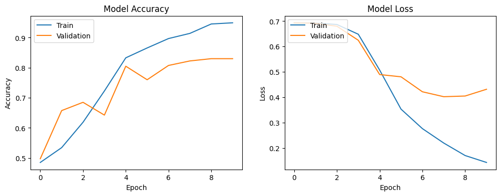

```python
#plot function for model accuracy and loss
def plot_model_history(history):
    # Plot training & validation accuracy values
    plt.figure(figsize=(12, 4))

    #accuracy plot
    plt.subplot(1, 2, 1)
    plt.plot(history.history['accuracy'])
    plt.plot(history.history['val_accuracy'])
    plt.title('Model Accuracy')
    plt.ylabel('Accuracy')
    plt.xlabel('Epoch')
    plt.legend(['Train', 'Validation'], loc='upper left')

    #loss plot
    plt.subplot(1, 2, 2)
    plt.plot(history.history['loss'])
    plt.plot(history.history['val_loss'])
    plt.title('Model Loss')
    plt.ylabel('Loss')
    plt.xlabel('Epoch')
    plt.legend(['Train', 'Validation'], loc='upper left')

    plt.show()

plot_model_history(history)
```

These trends confirm the effectiveness of the training process and the implemented strategies to maintain model generalization.

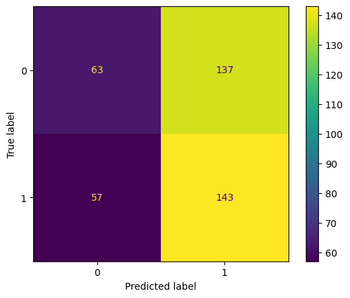

```python
from sklearn.svm import SVC
from sklearn.metrics import confusion_matrix, ConfusionMatrixDisplay

#flatten the padded sequences for use with svc
X_train_svc = train_padded.reshape(train_padded.shape[0], -1)
X_test_svc = test_padded.reshape(test_padded.shape[0], -1)

#initialize the svc
clf = SVC(random_state=0)

#train the svc
clf.fit(X_train_svc, y_train)

#predict with the svc
predictions = clf.predict(X_test_svc)

#compute confusion matrix
cm = confusion_matrix(y_test, predictions, labels=clf.classes_)

#display confusion matrix
disp = ConfusionMatrixDisplay(confusion_matrix=cm, display_labels=clf.classes_)
disp.plot()
plt.show()
```

```python
#evaluate the model
results = model.evaluate(test_padded, y_test)
print(f"Test Loss: {results[0]}")
print(f"Test Accuracy: {results[1]}")
print(f"Test AUC: {results[2]}")
```

```
13/13 ━━━━━━━━━━━━━━━━━━━━ 0s 3ms/step - AUC: 0.8815 - accuracy: 0.8204 - loss: 0.4640
Test Loss: 0.43192386627197266
Test Accuracy: 0.8299999833106995
Test AUC: 0.9017750024795532
```

**D 4. PREDICTIVE ACCURACY**

The predictive accuracy of the trained network was evaluated using accuracy and AUC (Area Under the Curve) metrics. The final test results demonstrated an accuracy of 83.00% and an AUC of 0.90.

These metrics indicate that the model is highly effective in distinguishing between positive and negative sentiments in the text data, showcasing its ability to generalize well to new, unseen data.

An accuracy of 83.00% means that the model correctly predicted the sentiment of the reviews 83.00% of the time. This high accuracy demonstrates the model's ability to classify the dataset's sentiments reliably.

The AUC of 0.90 further supports the model's predictive performance. The AUC metric evaluates the model's ability to distinguish between positive and negative classes. An AUC of 0.90 indicates that the model has a high degree of separability, meaning it is proficient in distinguishing between the two sentiment classes.

The combination of these metrics confirms the robustness and effectiveness of the trained neural network model in performing sentiment analysis on the combined dataset of Amazon and Yelp reviews.

**The Confusion Matrix**

The confusion matrix provides insight into the performance of the classification model by showing the number of correct and incorrect predictions for each class.

The color intensity in the matrix reflects the value magnitudes, with higher values appearing in yellow and lower values in dark purple, providing a visual representation of the model's prediction distribution.

**PART V**

**E. CODE**

The trained model was saved in the native Keras format; the code was provided by Dr. Sewell (Sewell, n.d.). This method is convenient for serializing the entire model, including its architecture, weights, and training configuration (optimizer, loss, and metrics).

The assignment is provided as a .ipynb file and a HTMLan document of the same content.

```python
#save the model using the native Keras format
model.save('D213_sentiment_analysis_model.keras')
```

**F. FUNCTIONALITY**

The neural network was designed and trained to perform sentiment analysis, a technique used to determine the emotional tone behind words. The model's primary function is to classify reviews as either positive or negative based on the text data provided.

Based on the text data provided, the model's primary function is to classify reviews as either positive or negative.

**Impact of Network Architecture:**

The architecture of the neural network significantly impacts its ability to perform sentiment analysis effectively:

**Embedding Layer:** This layer helps capture the semantic relationships between words, allowing the model to understand the context and meaning in the text data. By converting words into dense vectors, the model can process textual input more efficiently.

**Dropout Layers:** These layers randomly set a fraction of input units to zero during training, which helps in regularizing the model and preventing overfitting. This ensures that the model does not rely too heavily on specific features and can generalize better to unseen data.

**Dense Layers:** The network includes dense layers with 100 and 50 nodes, respectively. These layers help in learning complex patterns within the text data. The choice of the number of nodes strikes a balance between model complexity and computational efficiency.

**ReLU and Sigmoid Activation Functions:** ReLU activation functions in the hidden layers introduce non-linearity, enabling the model to learn complex patterns. The sigmoid activation function in the final layer outputs a probability score, suitable for binary classification tasks.

**EarlyStopping:** This stopping criterion monitors the validation loss and halts training when the performance stops improving, preventing overfitting and ensuring optimal model performance.

**Alignment with the Research Question:**

The designed neural network effectively addresses the research question "Can we determine customer sentiment by applying sentiment analysis to the combined Amazon and Yelp reviews datasets?" by accurately classifying the sentiment of combined reviews.

The model's architecture, including the embedding layer for feature extraction, dropout layers for regularization, and dense layers for classification, contributes to its robustness and generalization ability.

The high accuracy and AUC metrics obtained during evaluation confirm that the model can reliably determine customer sentiment, making it well-suited for sentiment analysis tasks on the combined datasets.

By leveraging the strengths of the neural network architecture, the model demonstrates its functionality and effectiveness in addressing the research question and providing valuable insights into customer sentiment.

**G. RECOMMENDATIONS**

1. Implement the model in production, deploying the trained model to the production environment to analyze real-time customer reviews from Amazon and Yelp. This will provide immediate insights into customer sentiment, allowing businesses to respond proactively to customer feedback.
2. Continuously monitor the model's performance on new data to ensure it maintains high accuracy and AUC metrics. Implement a feedback loop to retrain the model periodically with fresh data to keep it up-to-date with changing customer sentiments.
3. Explore additional feature engineering techniques to improve model performance further. For instance, incorporating more advanced natural language processing (NLP) techniques, such as sentiment-specific word embeddings or syntactic features, may enhance the model's ability to understand context and sentiment nuances.
4. Consider expanding the dataset to include reviews from other platforms and industries. This will not only enrich the training data but also increase the model's robustness and generalization capability across different types of customer feedback.
5. Use the sentiment analysis results to drive business decisions and strategies. For instance, identifying common themes in negative reviews can help you pinpoint areas for improvement while understanding positive feedback can highlight strengths to leverage in marketing campaigns.
6. Schedule regular maintenance and updates for the model to incorporate new data and address any potential issues. This will ensure the model remains accurate and relevant over time.

**PART VI**

**H. REPORTING**

The assignment is provided as a .ipynb file and an HTML document of the same content.

**I. SOURCES FOR THIRD-PARTY CODE**

Elleh, F. (n.d.-b). Avanced Data Analytics Task 2. https://westerngovernorsuniversity.sharepoint.com/. Retrieved February 2, 2025, from https://westerngovernorsuniversity.sharepoint.com/:p:/r/sites/DataScienceTeam/_layouts/15/Doc.aspx?sourcedoc=%7B50F5B89A-72F1-4964-9942-1F3790EF1D59%7D&file=D213%20Task%202%20Cohort%20Webinar%20PPT.pptx&action=edit&mobileredirect=true

Sewell, W. (n.d.). D213_Task2. https://westerngovernorsuniversity-my.sharepoint.com/. Retrieved February 4, 2025, from https://westerngovernorsuniversity-my.sharepoint.com/personal/william_sewell_wgu_edu/_layouts/15/onedrive.aspx?id=%2Fpersonal%2Fwilliam%5Fsewell%5Fwgu%5Fedu%2FDocuments%2FDocuments%2FD213%2FWebinars%2FD213%5FTask2%5FSentiment%5FAnalysis%5FAns%5FYelpOnly%2Ehtml&parent=%2Fpersonal%2Fwilliam%5Fsewell%5Fwgu%5Fedu%2FDocuments%2FDocuments%2FD213%2FWebinars&ga=1

**J. SOURCES**

GeeksforGeeks. (2024, June 20). Feedforward neural network. GeeksforGeeks. https://www.geeksforgeeks.org/feedforward-neural-network/#